# euclidian

### import library

```r
library(readr)  #Membaca data
library(dplyr)  #Data processing
library(DT)     #Menampilkan tabel agar mudah dilihat di browser
```

### Library yang dibutuhkan untuk hierarchical clustering

```r
library(stats)
library(cluster) #untuk melakukan cluster
```

# Pertama meng-input data

```r
dataHirarki <- read.csv("dataHirarki.csv",sep=";")
str(dataHirarki)
```

```
## 'data.frame':    5 obs. of  2 variables:
##  $ FiturX: int  1 4 1 3 5
##  $ FiturY: int  1 1 2 4 4
```

```r
dataHirarki
```

```
##   FiturX FiturY
## 1      1      1
## 2      4      1
## 3      1      2
## 4      3      4
## 5      5      4
```

## Menghitung Matriks Distance

Matriks distance merupakan matriks yang berisikan pasangan jarak antar objek yang dihitung dengan Euclidian Distance. Dalam R, matriks distance dapat dihitung dengan menggunakan fungsi dist()

```r
d <- dist(dataHirarki, method = "euclidean")
d
```

```
##          1        2        3        4
## 2 3.000000
## 3 1.000000 3.162278
## 4 3.605551 3.162278 2.828427
## 5 5.000000 3.162278 4.472136 2.000000
```

# Metode 1. Single Linkage

Untuk melakukan metode Single Linkage, dalam R dapat menggunakan fungsi hclust() kemudian memasukkan argument ‘single’ pada parameter ‘method’

```r
hc_single <- hclust(d = d, method = "single")
hc_single
```

```
##
## Call:
## hclust(d = d, method = "single")
##
## Cluster method   : single
## Distance         : euclidean
## Number of objects: 5
```

# MEMBUAT DENDOGRAM

Ketika menggunakan R, untuk membuat dendogram cukup dengan menggunakan fungsi plot(); sedangkan ketika menghitung manual dengan cara membuat plot antara objek/pengamatan dan mengubungkannya ketika antar objek/pengamatan tergabung menjadi satu klaster berdasarkan jarak minimum yang telah dihitung.

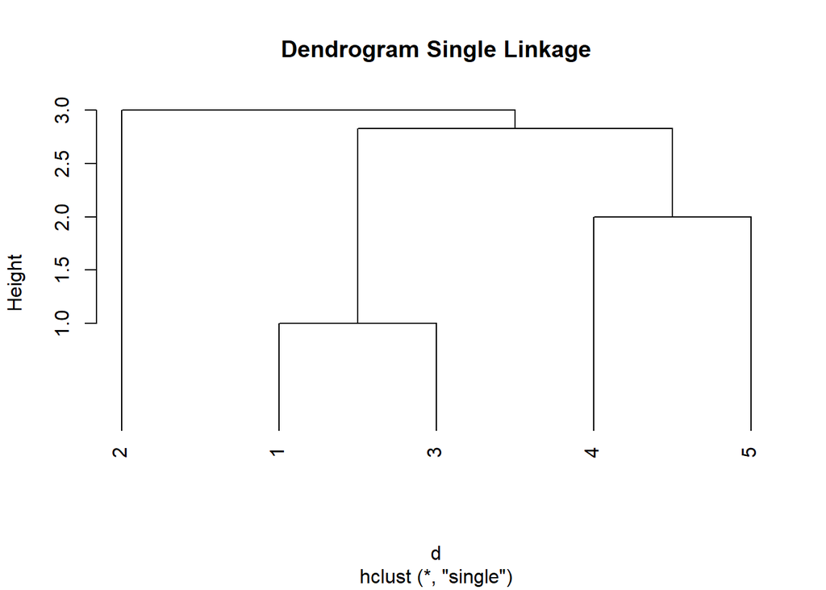

```r
plot(hc_single, main = "Dendrogram Single Linkage", hang = -1 ) #Menampilkan Dendogram
```

# Metode 2. Complete Linkage

```r
hc_complete <- hclust(d = d, method = "complete")
hc_complete
```

```
##
## Call:
## hclust(d = d, method = "complete")
##
## Cluster method   : complete
## Distance         : euclidean
## Number of objects: 5
```

# MEMBUAT DENDOGRAM

Ketika menggunakan R, untuk membuat dendogram cukup dengan menggunakan fungsi plot(); sedangkan ketika menghitung manual dengan cara membuat plot antara objek/pengamatan dan mengubungkannya ketika antar objek/pengamatan tergabung menjadi satu klaster berdasarkan jarak minimum yang telah dihitung.

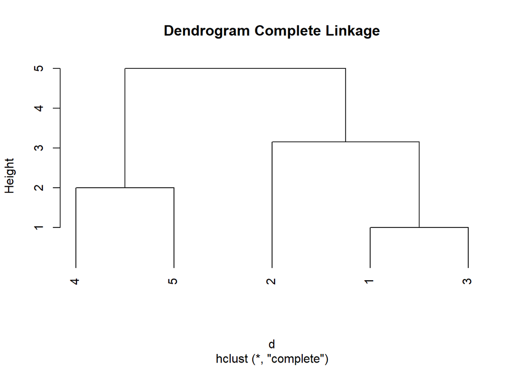

```r
plot(hc_complete, main = "Dendrogram Complete Linkage", hang = -1) #Menampilkan Dendogram untuk Complete
```

# Metode 3. Average Linkage

```r
hc_average <- hclust(d = d, method = "average")
hc_average
```

```
##
## Call:
## hclust(d = d, method = "average")
##
## Cluster method   : average
## Distance         : euclidean
## Number of objects: 5
```

# MEMBUAT DENDOGRAM

Ketika menggunakan R, untuk membuat dendogram cukup dengan menggunakan fungsi plot(); sedangkan ketika menghitung manual dengan cara membuat plot antara objek/pengamatan dan mengubungkannya ketika antar objek/pengamatan tergabung menjadi satu klaster berdasarkan jarak minimum yang telah dihitung.

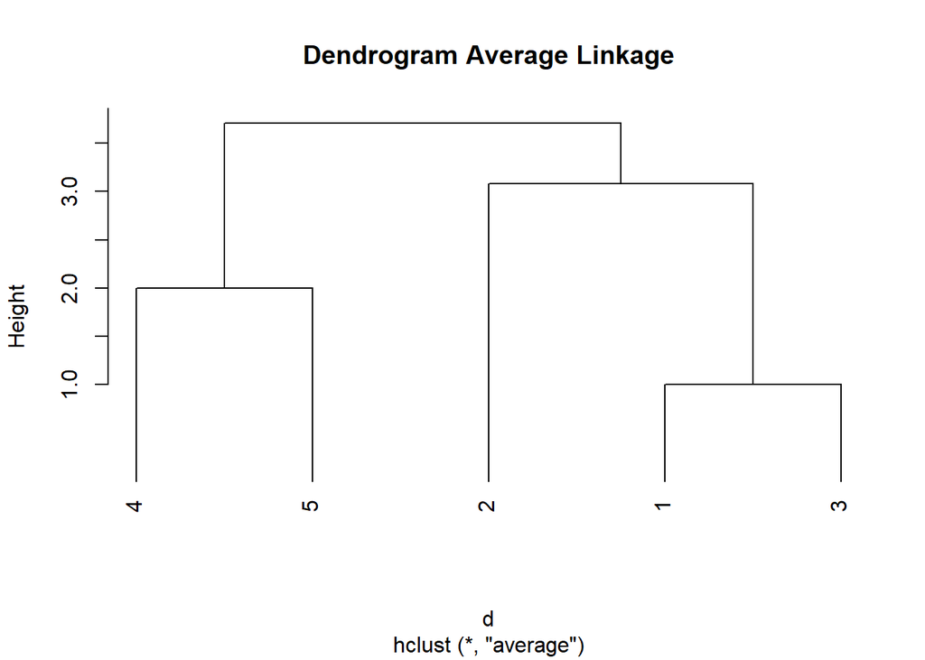

```r
plot(hc_average, main = "Dendrogram Average Linkage", hang =-1)#menampilkan Dendogram
```

Kedua fungsi ini sangat mirip (hclust dan agnes) namun, dengan fungsi agnes kita juga bisa mendapatkan koefisien aglomeratif, yang mengukur jumlah struktur pengelompokan yang ditemukan (nilai lebih dekat ke 1 menyarankan struktur pengelompokan yang kuat).

### Koefisien Aglomeratif

```r
hc2 <- hc_average
hc2$ac
```

[output not shown]

### membandingkan beberapa metode aglomeratif

# membuat vector untuk membandingkan metode aglomeratif

```r
m <- c( "average", "single", "complete")
names(m) <- c( "average", "single", "complete")
```

# membuat fungsi untuk menghitung koefisien

# import library purrr untuk melakukan iterasi

```r
library(purrr)
```

```r
ac <- function(x) {
    agnes(dataHirarki, method = x)$ac
}
map_dbl(m, ac)
```

```
##   average    single  complete
## 0.5098048 0.4000000 0.6335089
```

## dari hasil perbandingan diatas didapat metode complete memiliki koefisien aglomeratif yang lebih tinggi dibandingkan metode lainnya

# berikut dendogramnya

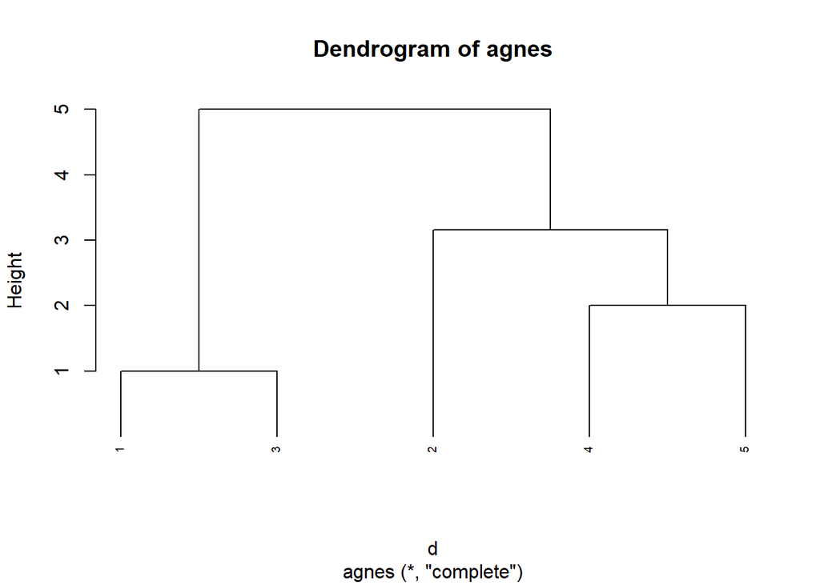

```r
hc3 <- agnes(d, method = "complete")
pltree(hc3, cex = 0.6, hang = -1, main = "Dendrogram of agnes")
```